# Regresión lineal múltiple con los resultados de las primarias 2019

Héctor Meleiro

22 de mayo de 2018

## Introducción.

A continuación se presentan los resultados de una regresión lineal múltiple realizada con los datos de las primarias para la lista de las elecciones autonómicas a la Comunidad de Madrid 2019. El modelo trata de dilucidar cuáles son las variables que más han influido en el número de puntos obtenidos por cada candidato. Por lo tanto, la variable a explicar es el número de puntos totales y las variables independientes introducidas en el modelo son las siguientes:

- Número de seguidores
- La posición en la lista
- La posición de corriente en la lista
- La corriente a la que se pertenece
- El sexo
- El número de votos recibidos en las cuatro primeras posiciones

Adicionalmente se han añadido las variables para controlar los datos atípicos de Tania Sánchez, Ramón Espinar y José Manuel López por considerarlos candidatos de una notoriedad muy por encima del resto.

## Gráficos de dispersión.

Aquí se pueden observar los gráficos de dispersión de la variable dependiente con las independientes continuas. como se observa, las que tienen una clara corelacion lineal con el número de puntos obtenidos son las de posición de salida (P. SAL.) y posición de familia (P-S-FAM). Las otras dos parecen tener una corelación logarítmica o cuadrática.

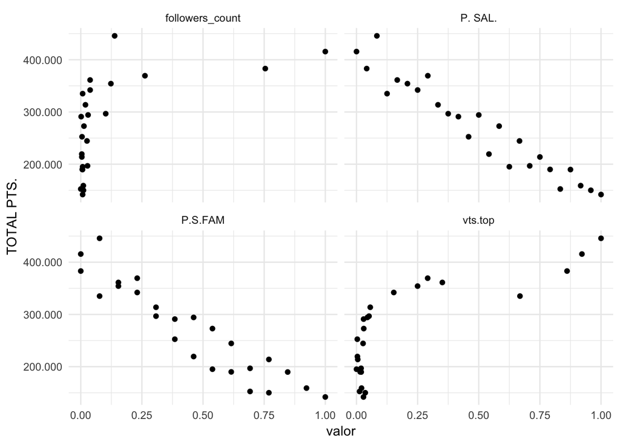

## Resumen del modelo

En términos generales el modelo es válido. El p-valor del modelo (< 2.2e-16) es menor a 0.05 por lo que considerando un nivel del significación del 5% se puede rechazar la hipótesis nula. Además la cercanía al 1 del R² (0.9967) y el R² ajustado (0.9948) indican un buen ajuste del modelo a los datos.

La variable con un p-valor más bajo (y por lo tanto la más significativa en el modelo) es la de ser mujer y la posición de salida. El estimador de estas variables nos dice que manteniendo el resto de variables inalteradas ser mujer suma 34.626 puntos y ser primero en la lista 297.239. El signo de este último estimador es negativo en el resumen del modelo porque la primera posición se lee como 1 y por lo tanto más bajo que 25 (la última posición de la lista). El modelo también nos muestra como variables significativas el número de seguidores en Twitter.

El modelo también sugiere que a Tania Sánchez y a Ramón Espinar se les ha penalizado en esta elección. Es decir, el modelo indica que para la posición de salida en la que figuraban, los seguidores de Twitter que tienen, su sexo, y el resto de variables contempladas en el modelo estos dos candidatos han obtenido peor resultado por ser ellos. En concreto 284.182 puntos menos en el caso de Tania y 186.529 en el caso de Ramón Espinar.

```
##
## Call:
## lm(formula = `TOTAL PTS.` ~ ., data = modelo)
##
## Residuals:
##    Min     1Q Median     3Q    Max
## -11955  -2848      0   2611   9420
##
## Coefficients:
##                 Estimate Std. Error t value Pr(>|t|)
## (Intercept)       349308       5507  63.426  < 2e-16 ***
## followers_count   276465      61217   4.516 0.000410 ***
## `P. SAL.`        -297239      31964  -9.299 1.29e-07 ***
## P.S.FAM            64725      35161   1.841 0.085516 .
## fam1               13645       4474   3.050 0.008110 **
## mujer1             34626       2802  12.359 2.89e-09 ***
## TS1              -284182      54560  -5.209 0.000106 ***
## RE1              -186529      42309  -4.409 0.000508 ***
## JM1                -2545      13220  -0.193 0.849929
## vts.top            27947       8197   3.409 0.003884 **
## ---
## Signif. codes:  0 '***' 0.001 '**' 0.01 '*' 0.05 '.' 0.1 ' ' 1
##
## Residual standard error: 6455 on 15 degrees of freedom
## Multiple R-squared:  0.9967, Adjusted R-squared:  0.9948
## F-statistic: 506.6 on 9 and 15 DF,  p-value: < 2.2e-16
```

## Anexo.Gráficos. Validación del modelo.

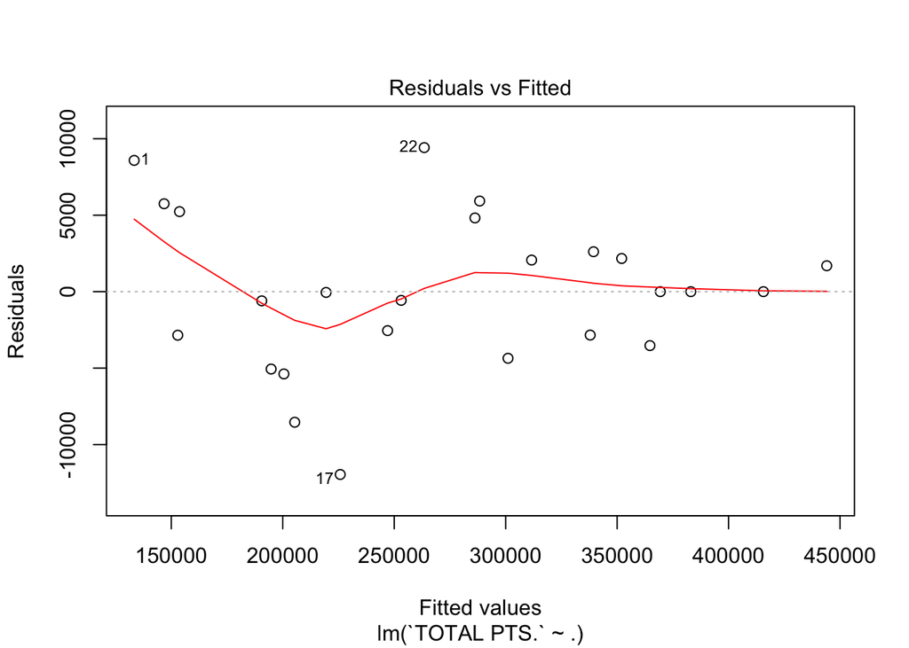

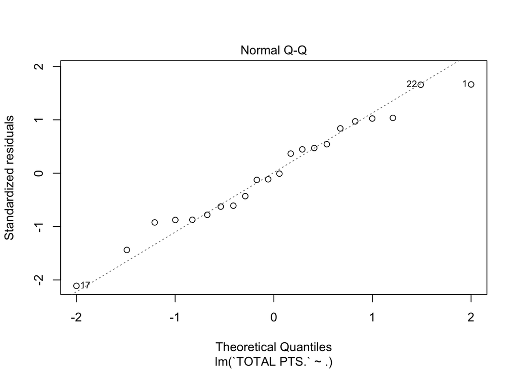

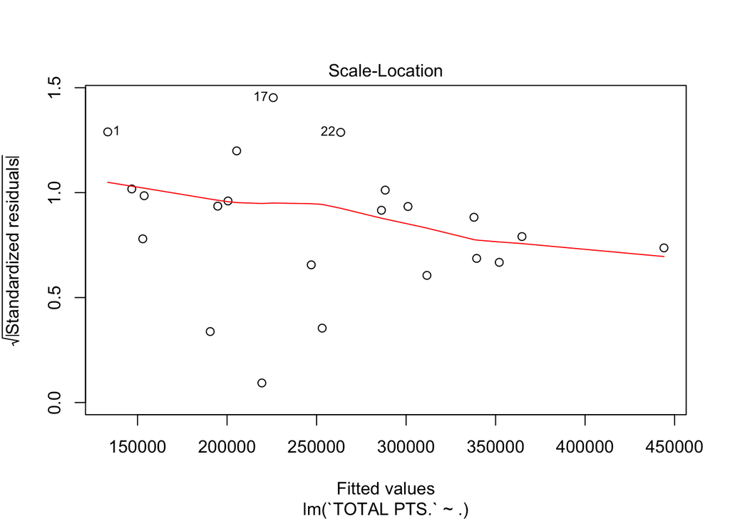

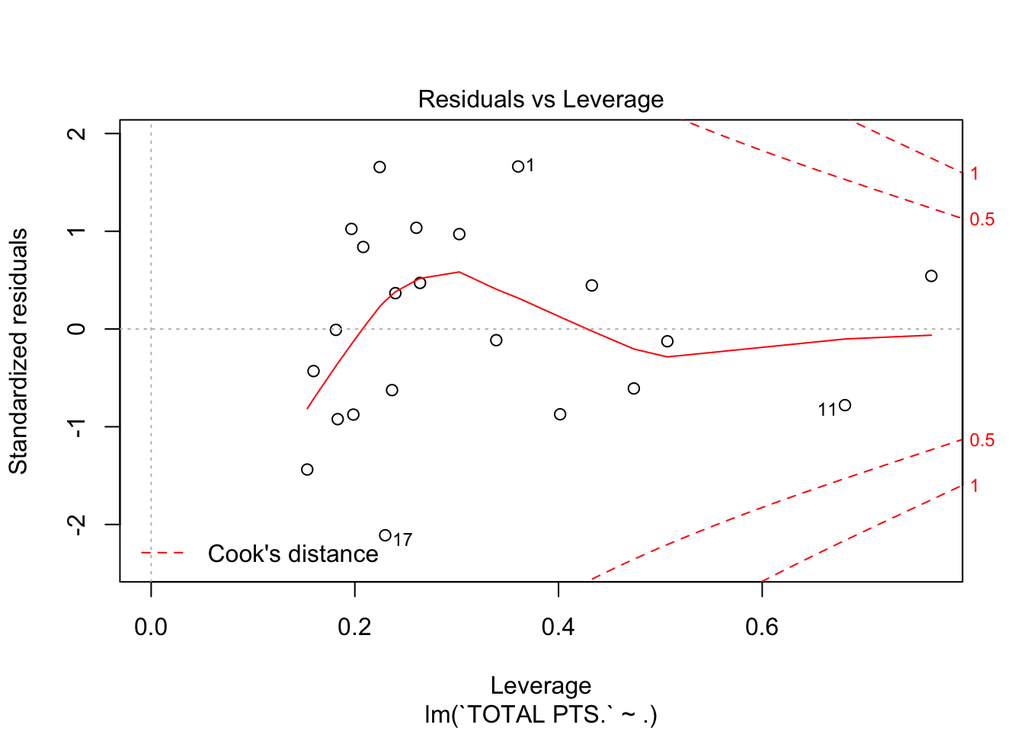